# Лабораторная работа № 6

Динамическая маршрутизация RIP

Баранов Никита Дмитриевич

1132242977@rudn.ru

Российский университет дружбы народов им. Патриса Лумумбы

2026-09-14

# Информация

## Докладчик

- Баранов Никита Дмитриевич
- Студент РУДН
- 1132242977@rudn.ru

# Цель и задачи

## Цель работы

- Изучить RIP/RIPng и настроить обмен маршрутами в сетях IPv4 и IPv6.

## Основные этапы

# Ход работы

## В GNS3 построено кольцо из четырёх маршрутизаторов FRR с двумя конечными сетями

- Кольцо из четырёх FRR соединяет две удалённые локальные сети.

[figure not shown]

- На экране показан результат соответствующего этапа настройки.

[figure not shown]

- Первый маршрутизатор адресован сразу в трёх смежных сетях.

[figure not shown]

- На экране показан результат соответствующего этапа настройки.

[figure not shown]

- На экране показан результат соответствующего этапа настройки.

[figure not shown]

- Третий FRR связывает транзитные каналы с конечным сегментом.

[figure not shown]

- На экране показан результат соответствующего этапа настройки.

[figure not shown]

## На FRR-4 в краткой таблице одновременно показаны IPv4 и IPv6 на транзитных интерфейсах

- IPv4/IPv6-адреса транзитных портов видны в одной таблице.

[figure not shown]

## В конфигурации FRR включён router rip version 2 и объявлены eth0 и eth1

- На экране показан результат соответствующего этапа настройки.

[figure not shown]

## Команда show ip rip выводит локальные сети, соседние шлюзы, таймеры и источники информации

- На экране показан результат соответствующего этапа настройки.

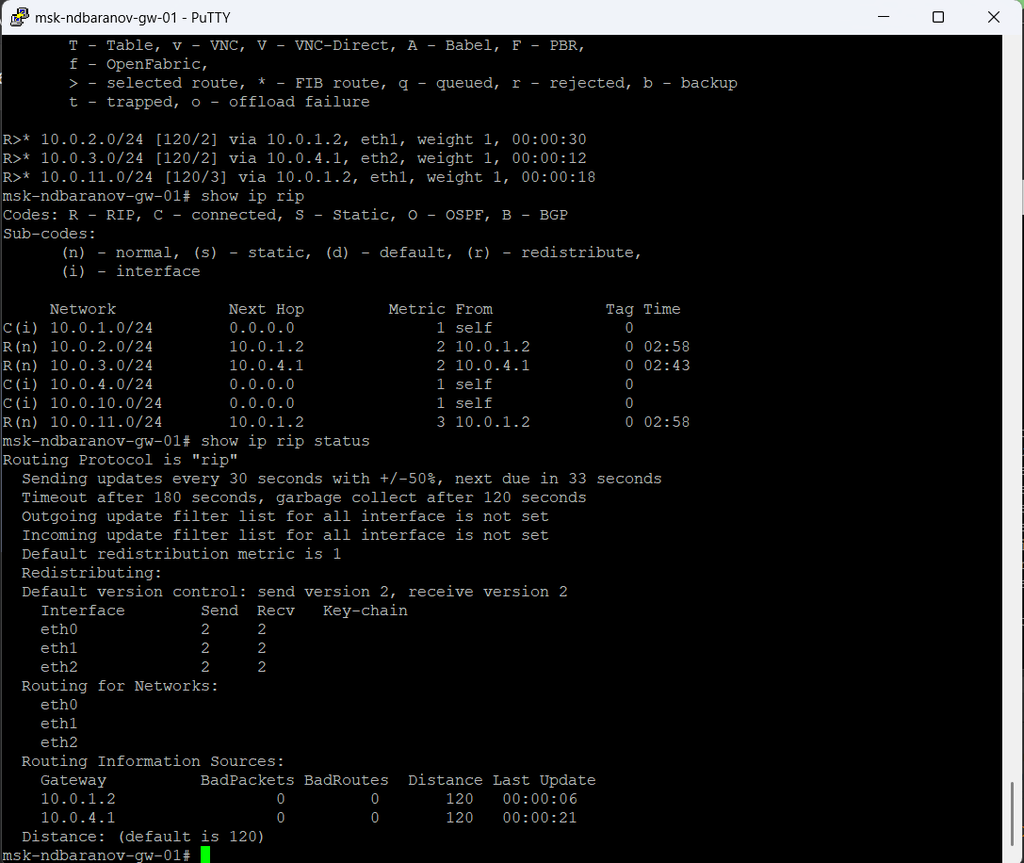

- RIPv2 периодически рассылает Response на 224.0.0.9.

[figure not shown]

- На экране показан результат соответствующего этапа настройки.

[figure not shown]

## На маршрутизаторе проверена IPv6-таблица и выполнен traceroute до удалённого префикса

- IPv6-маршрут проходит через link-local адреса соседей.

[figure not shown]

## Wireshark декодирует RIPng Command Response, отправленный на ff02::9

- На экране показан результат соответствующего этапа настройки.

[figure not shown]

- На экране показан результат соответствующего этапа настройки.

[figure not shown]

## Для самостоятельного варианта собрана топология с четырьмя FRR и двумя VPCS, где между частью маршрутизаторов существуют резервные линии

- Самостоятельный стенд содержит основные и резервные пути.

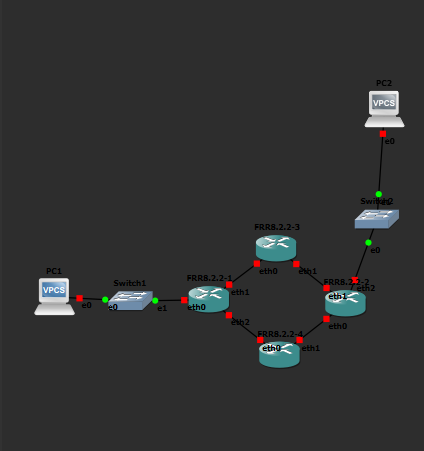

- На экране показан результат соответствующего этапа настройки.

[figure not shown]

- PC2 размещён в 10.10.1.64/28 и 2001:db8:1:6::/64.

[figure not shown]

- На экране показан результат соответствующего этапа настройки.

[figure not shown]

## После запуска маршрутизации рабочая схема показана с зелёными соединениями по основным и резервным путям

- На экране показан результат соответствующего этапа настройки.

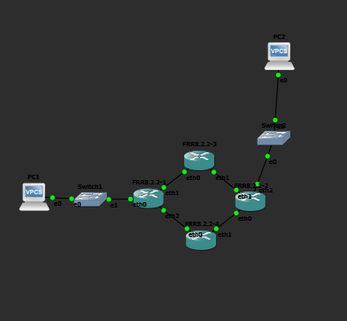

[figure not shown]

## Команда show ip route rip содержит удалённые подсети с кодом R, next hop и метрикой

- На экране показан результат соответствующего этапа настройки.

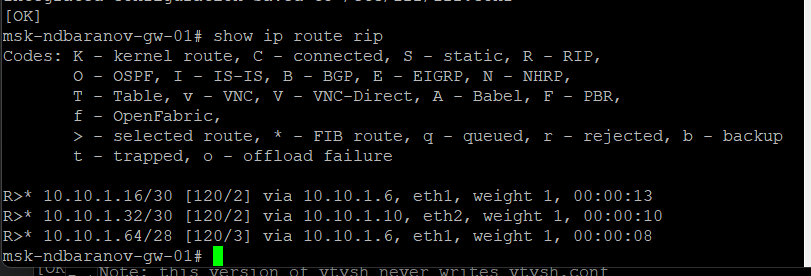

## В show ipv6 ripng перечислены локальные и полученные IPv6-префиксы, интерфейсы и число переходов

- RIPng установил маршруты к удалённым IPv6-префиксам.

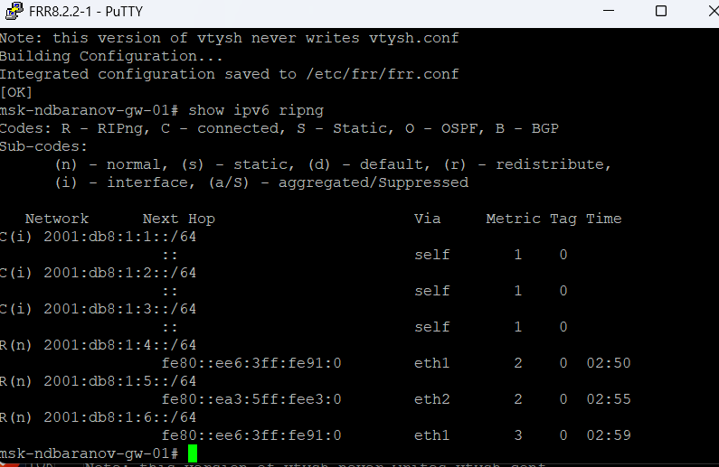

# Результаты

## Итоги работы

- Цель работы достигнута. Изучить RIP/RIPng и настроить обмен маршрутами в сетях IPv4 и IPv6 Полученные результаты подтверждают работоспособность собранной схемы и корректность выполненной настройки.

## Спасибо за внимание